# P1 - Eletromagnetismo

## Questão 1

#### (Corrente e Densidade de Corrente )

### O módulo $J(r)$ da densidade de corrente em um certo fio cilíndrico é dado por $J(r) = Br$, onde $r$ é a distância radial a partir do centro do fio em metros e $B = 2\cdot 10^5 \ A/m^3$.

### Qual é a corrente que passa em um anel concêntrico com o fio, com $10\mu m$ de largura, situado a uma distância radial de $1.2mm$ do centro do fio ?

## Solução:

A densidade de corrente é dada por $$J(r) = \frac{di}{dA}$$ Como estamos trabalhando com um fio de seção reta circular, teremos: $$dA = 2\pi r dr$$ logo $$di = J(r) \ 2\pi r dr$$

Assim, podemos calcular a correte através da integral: $$i = \int^b_a 2\pi r J(r) dr$$

onde $a = 1.2\cdot 10^{-3}m$ é o raio interno do anel e $b = 1.21\cdot 10^{-3} m$ é o raio externo do anel.

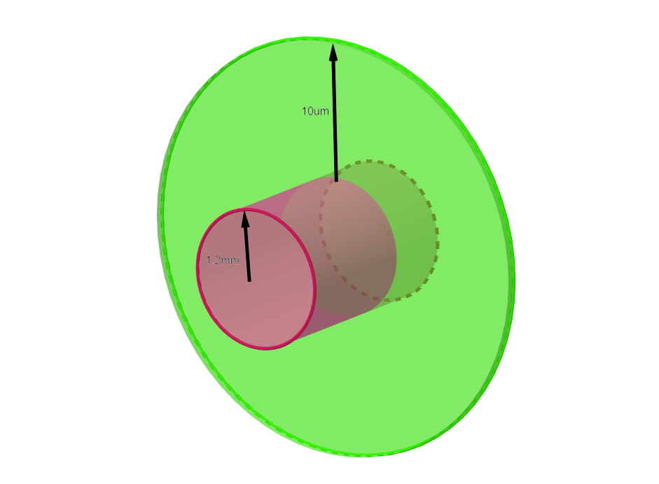

```python
from IPython.display import Image
Image("q1.png")
```

```python
from math import *
import sympy as sp
import numpy as np

B = 2e5
a = 1.2e-3
b = 1.21e-3

i, r, J = sp.symbols("i r J")

J = lambda r: B*r

i = sp.integrate(2*sp.pi*r*J(r),(r,a,b))

print("i = {:.5e} A ".format(i.evalf()))
```

```
i = 1.82468e-5 A
```

logo temos que $$ i = 18.25 \mu A$$

## Questão 2

#### ( Distribuição Contínuas de Carga, Potêncial Elétrico, Campo Elétrico, Carga Elétrica)

### Um fio retilíneo fino, de comprimento $2L$, está postado ao longo do eixo cartesiano $X$, com seu centro na origem. A densidade linear de carga do tal fio é dada por: $$\rho_L(x) = \frac{\rho_0 |x|}{L}$$ onde $\rho_0 = cte = 4$

### a) Calcule o potencial eletroestático $V(x=0,y,z=0)$ para um ponto arbitrário no eixo cartesiano $y$ com ordenada $y>0$. Sendo $V(\infty) = 0$ e $L=2m$.

### b) Calcule, a componente $y$ do vetor campo elétrico $E_y(x=0,y,z=0)$ em tal ponto.

### c) Determine, a carga total de tal fio.

## Solução:

Calculando o potencial, vamos calcular somando os potenciais infinitesimais em cada partícula do fio no ponto $(0,y,0)$ com $y>0$ $V = \int_{fio} dV $ $$ dV = k\frac{dq}{r}$$

onde podemos trocar o diferencial das cargas por densidade $$ dq = \rho_L(x) dx$$

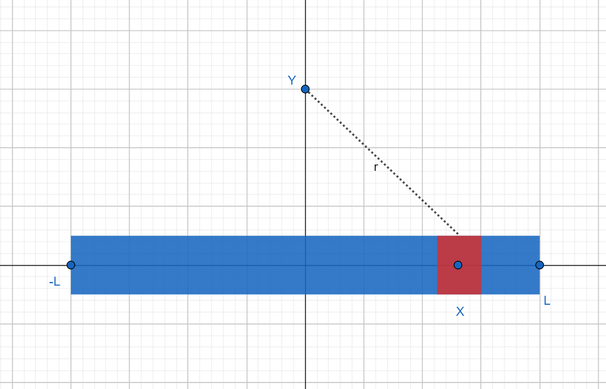

```python
Image("q2.png")
```

Logo vamos ter $$V = \int_{fio} k\frac{\rho_L(x)}{r} dx $$ $$V = \int_{-L}^L k\frac{\rho_0 |x| }{L\sqrt{x^2+y^2}} dx $$ tirando tudo que é constante da integral ficaremos com $$V = k\frac{\rho_0}{L} \cdot \int_{-L}^L \frac{|x|}{\sqrt{x^2+y^2}} dx $$

```python
L, x, y, rho0, k,V= sp.symbols("L x y rho_0 k V")
e0 = 8.85e-12
L = 2
rho0 = 4
k = 1/(4*sp.pi*e0)

I = sp.integrate(abs(x)/(sp.sqrt(x**2 + y**2)),(x,-L,L))

V = (k*rho0/L) * I

V.evalf(4)
```

$\displaystyle 7.194 \cdot 10^{10} \left(0.25 y^{2} + 1\right)^{0.5} - 3.597 \cdot 10^{10} \left(y^{2}\right)^{0.5}$

Tendo a tensão podemos calcular a componente $y$ do campo elétrico. Dado que : $$\vec{E} = -\nabla V$$ $$ E_y = - \frac{\partial V}{\partial y} $$

```python
Ey = lambda y: - V.diff(y)
Ey(y).evalf(4)
```

$\displaystyle - \frac{1.798 \cdot 10^{10} y}{\left(0.25 y^{2} + 1\right)^{0.5}} + \frac{3.597 \cdot 10^{10} \left(y^{2}\right)^{0.5}}{y}$

```python
sp.plot(Ey(y),(y,-10,10), title= "Comportamento do Campo Elétrico E(y)", xlabel = "Descolamento do Ponto Y", ylabel=" ")
```

[figure not shown]

```
<sympy.plotting.plot.Plot at 0x18764149b50>
```

Podemos interpretar com o gráfico, que conforme o ponto $Y$ vai se afastando da distribuição linear de carga, o Campo Elétrico também vai caindo com as dadas proporções. A assintota da parte negativa, no 3 quadrante, poderia indicar que estamos botando o ponto $Y$ a uma distância abaixo da origem na distribuição de carga, acaba acarretando no mesmo comportamento de decaimento do Campo, sindo Simétrico.

Porém como queremos uma análise para $y>0$, teremos:

```python
sp.plot(Ey(y),(y,0,10), title= "Comportamento do Campo Elétrico E(y)", xlabel = "Descolamento do Ponto Y", ylabel="E(y)")
```

[figure not shown]

```
<sympy.plotting.plot.Plot at 0x18763ae6a30>
```

Para obter a carga total agora, basta integrar a densidade na barra toda: $$Q = \int^L_{-L} \rho_0 \frac{|x|}{L} dx $$

```python
Q = rho0/L * sp.integrate(abs(x),(x,-L,L))
Q
```

$\displaystyle 8.0$

$$Q = 8C$$

## Questão 3

#### (Lei de Gauss, Campo Elétrico, Distribuição de Carga)

### Esboce um gráfico para o campo elétrico em função do raio $r$ nas gaussiana azul e verde no desenho abaixo, para modelar a Simétria Esférica da esfera vermelha maciça com cargas uniformemente distribuídas.

[figure not shown]

```python
Image("q3quest.png")
```

## Solução:

Para calcular o campo elétrico dentro da esfera Vermelha, ou seja, na gaussiana Azul vamos usar a lei de Gauss $$\oint \vec{E}\cdot d\vec{A} = \frac{q_{int}}{\epsilon_0}$$ A simétria esférica é radial, isso faz com que o vetor campo elétrico faça $0°$ ou $180°$ com o vetor $d\vec{A}$, afentando então somente o sinal do campo elétrico uma vez que o $\cos{0°} = 1$ e $\cos{180°} = -1$, vamos adotar aqui uma distribuição de cargas positivas, logo $\vec{E} \parallel d\vec{A}$ ambos saindo da esfera, fazendo $0°$.

$$ E = \frac{Q}{\epsilon_0 \cdot 4\pi \ r^2}$$

Calculando $r \leq R$:

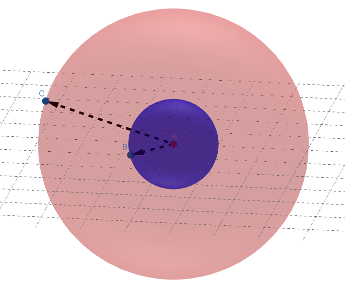

```python
Image("q3r.png")
```

A gaussiana Azul é englobada apenas pela esfera carregada, então vamos usar a densidade volumétrica de carga. $$\rho_v = \frac{Q_{int}}{V_{int}}$$

$$Q = \rho \cdot \frac{4\pi r^3}{3}$$

Substituindo na expressão do campo elétrico, teremos:

$$E_1 = \left(\rho \cdot \frac{4\pi r^3}{3} \right) \cdot \frac{1}{\epsilon_0 \ 4\pi r^2}$$

Simplificando $$E_1 = \frac{\rho}{3\epsilon_0} \cdot r $$

Calculando agora a gaussiana Verde $r \geq R$:

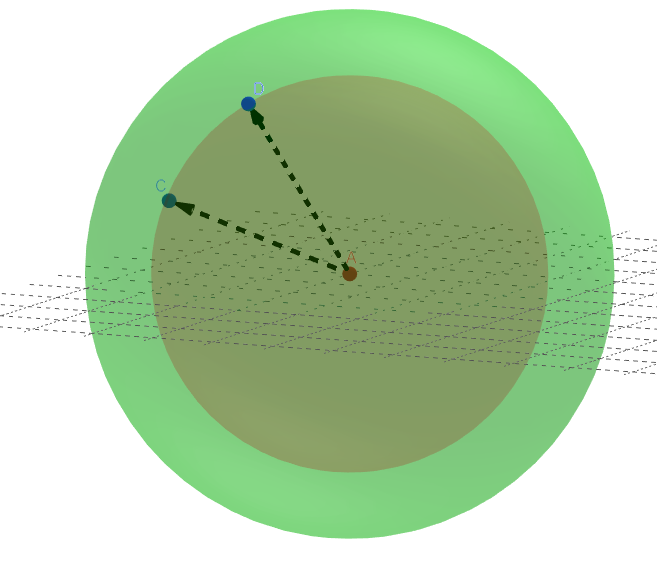

```python
Image("q3rr.png")
```

A gaussiana nesse caso, engloba a esfera carregada. Dessa forma, a carga interna será: $$ Q = \rho \frac{4\pi R^3 }{3} $$ onde $R$ é o raio da esfera vermelha, a esfera carregada e $\rho$ é a densidade volumétrica. Substituindo na expressão de campo elétrico $$ E_2 = \left( \rho \frac{4\pi R^3 }{3}\right) \cdot \frac{1}{\epsilon_0 \ 4\pi r^2}$$

Simplificando

$$ E_2 = \frac{\rho}{3\epsilon_0} \cdot \frac{R^3}{r^2} $$

```python
R = sp.symbols("R")
#valores hipteticos para conseguir ver o comportamento do gráfico
rho = 3e-3
R = 4
E1 = lambda r: rho/(3*e0) * r
E2 = lambda r: rho/(3*e0) * (R**3)/(r**2)
sp.plot((E1(r),(r,0,R)),(E2(r),(r,R,20)),title = "Campo Elétrico em Simetria Esférica em Esfera Maciça",xlabel = "r",ylabel = "E(r)")
```

[figure not shown]

```
<sympy.plotting.plot.Plot at 0x187634647c0>
```

Podemos observar que no primeiro momento temos uma reta, isso porque a função $E_1$ é linear, e no segundo momento em $E_2$ temos que o campo cai com o quadrado da distância, em um experimento mental, podemos entender que do centro da esfera maciça até o máximo comprimento do raio $R$, que nesse caso foi de $4m$, temos um o campo elétrico crescente e linear, a partir do momento que pegamos um ponto externo a esfera e vamos distanciando ele, teremos que o campo elétrico irá diminuir com o quadrado dessa distância.